# Coursework Report

*N* removed NAs: 3

*N* removed typo: 1

*N* removed <18: 34

*N* total clean: 112

| Group | *N* | *M*<sub>age</sub> | *M*<sub>rating</sub> |
| --- | --- | --- | --- |
| Control | 59 | 20.8 | 5.95 |
| Experim | 53 | 21.2 | 5.24 |

**Main analysis results**

*t*(110) = 4.93, *p* < .001

[interactive chart not shown]

[figure not shown]

[interactive chart not shown]

# Coursework Report

Analysing Data, Spring 2020

# Methods

## Participants

```
## # A tibble: 2 x 6
##   group            n mean_age sd_age min_age max_age
##   <fct>        <int>    <dbl>  <dbl>   <dbl>   <dbl>
## 1 Control         59     20.8   2.54      18      28
## 2 Experimental    53     21.2   2.22      18      29
```

**Figure 1. A table of participant descriptives by experimental condition.**

## Design

The hypothesis for this experiment was does the colour red effect women’s perceptions of a man’s attractiveness?. After viewing a photo of a man against either a red or white background for 5 seconds, the female participants were asked three questions; “How attractive do you think this person is?”, “How pleasant is this person to look at?” and “If I were to meet the person in this picture face to face, I would think he is attractive.” Women then rated these items on a 9-point scale ranging from 1 to 9, with 1 being the lowest score rating, or least attractive, and 9 being the highest or most attractive.

Definitively, this test examined if a women’s rating on the attractiveness of men, on a scale of 1-9, is affected by a red frame surrounding the photo of the target man. To analyse the data, comparing means with an independent measures t-test, was used.

# Results

A composite index of perceived attractiveness was calculated by averaging the scores obtained from the three test items. The mean of average attractiveness ratings across the three questions for the control group viewing a white background was 5.95 while the mean attractiveness ratings for the experimental group viewing a red background was 5.24. The highest average attractiveness rating in the control group was 7.67 (rounded to two decimal places) and the lowest average was 4.33 (rounded to two decimal places). The highest average attractiveness score in the experimental condition was 7 and the lowest average attractiveness score was 3.67 (rounded to two decimal places).

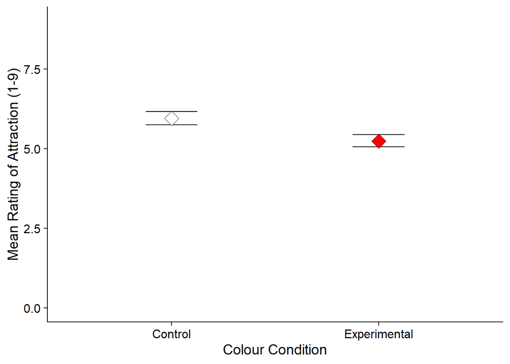

**Figure 2. Mean overall attractiveness rating of experimental and control conditions (+/-1 SEM).**

# Discussion

The study revealed that compared to the participant of the red condition, those in the white condition rated the target man as more attractive overall. With participants of the red condition giving an average attractiveness rating of 5.24 and participants of the white condition giving an average of 5.95. The results support the hypothesis that the colour of the frame does influence perceived attractiveness ratings however in the reverse of the expected pattern, in that those in the white condition gave higher attractiveness ratings. In comparison to an identical study (Elliot et al.,2010), findings differed in that a significant difference was found between the colour conditions, however in the expected pattern; participants in the red condition rated the target men as more attractive than those in the white condition. This difference suggests there are perhaps flaws in the design of either of the studies or that the colour red is not as influential as it seems. Further research should be done in this area to consolidate the conclusion that the colour red has an effect on perceived attractiveness.

Hesslinger et al. (2015) replicated Elliot et al.’s (2010) study and found women gave men associated with the colour red higher ratings on perceived attractiveness than those associated with the colour white. However the small difference was not statistically significant. This further suggests that the colour red is not as influential over perceived attractiveness as initially thought. It additionally suggests that there could be flaws in our study and there may have been variables that were not controlled accurately. For example, due to the independent measures design, participants of the white condition may have, as a group, had a higher standard of attractiveness.

The lack of evidence suggesting the colour red has an influence on perceived attractiveness is also seen in Peperkoorn et al.’s (2015) study on males rating a women in differing shirt colours. Their study found the women in red did not receive higher ratings and instead, consistent with our results, Peperkoorn et al. (2015) found a small but significant white effect on attractiveness. These findings support our results suggesting there are not flaws to our study and supporting the conclusion that there is not an influence of colour on perceived attractiveness or perhaps even an effect of the colour white on attractiveness. Future research could look further and develop the potentiality that white may have an effect on perceived attractiveness of both men and women.

Our study used participants between the ages of 18 and 29, which would suggest that the majority of our participants would be looking for short term relationships not long term, hindering their requirements for mate choice and consequently their attractiveness requirements. This weakens the validity of our study and therefore, if necessary, future research could also asses the influence of colour on attractiveness on older participants, exceeding the age of 30 who would more likely be looking for a long term relationship rather than short term, who perhaps have a more consolidated perception of attractiveness. As the majority of studies in this area use heterosexual particpants, it could be interesting to explore if colour effects percived attractiveness among homosexuals.

Research by Penton-Voak et al. (1999) suggests that female mate preference varies across the menstrual cycle. This variable was difficult to control in our study and potentially varied with our experimental variable, effecting the internal validity of our study. This is something that is hard to have complete control over and accordingly future research would not be worth considering.

In conclusion, despite predictions, our findings found a significant white effect on perceived attractiveness of the target male. The mixed findings in this area suggest the likelihood that there is an effect of the colour red on perceived attractiveness is very small indicating further research in this field would not be necessary.

# References

Elliot, A., Niesta Kayser, D., Greitemeyer, T., Lichtenfeld, S., Gramzow, R., Maier, M., & Liu, H. (2010). Red, rank, and romance in women viewing men. *Journal Of Experimental Psychology: General, 139*(3), 399-417. doi: 10.1037/a0019689

Hesslinger, V., Goldbach, L., & Carbon, C. (2015). Men in red: A reexamination of the red-attractiveness effect. *Psychonomic Bulletin & Review, 22*(4), 1142-1148. doi:10.3758/s13423-015-0866-8

Penton-Voak, I., Perrett, D., Castles, D., Kobayashi, T., Burt, D., Murray, L., & Minamisawa, R. (1999). Menstrual cycle alters face preference. *Nature, 399*(6738), 741-742. doi: 10.1038/21557

Peperkoorn, L., Roberts, S. and Pollet, T., 2016. Revisiting the Red Effect on Attractiveness and Sexual Receptivity. *Evolutionary Psychology, 14*(4). doi:10.1177/1474704916673841